# Filtros de Kalman

- Los filtros de Kalman son esencialmente modelos escondidos de Márkov donde tanto la dsitribución de emisíón como la distribución de la transición en la cadena escondida de Márkov son Gaussianas.
- ¡Esto significa que el espacio de estados de la cadena escondida de Márkov es continuo!
- ¡La cadena de Márkov sigue siendo a tiempo discreto!

Consideramos una cadena de Márkov $\left\{ \pmb{Y}_n \right\}_{n=1}^{\infty}$ que toma valores en $\mathbb{R}^d$ con kernel de transición de probabilidad

$$ P(\pmb{y},C) = \left(2\pi\right)^{-d/2}\det(\textbf{Q})^{-1/2}\int_C exp\left( -0.5(\pmb{u}-\textbf{A}\pmb{y})' Q^{-1} (\pmb{u}-\textbf{A}\pmb{y}) \right) \mathrm{d}\pmb{u} $$

es decir

$$ \pmb{Y}_n\, | \, \pmb{Y}_{n-1}\sim \text{Normal}_d\left( \textbf{A}\pmb{Y}_{n-1},\,\textbf{Q} \right), $$

para $\pmb{y}\in\mathbb{R}^d$, $C\subset \mathbb{R}^d$, $\textbf{A}$, $\pmb{Q}$ matrices $d\times d$ dimensionales con $\textbf{Q}$ positivo semi-definida. Por otro lado consideramos un proceso estocástico $\left\{ \pmb{X}_n \right\}_{n=1}^\infty$ que toma valores en $\mathbb{R}^k$ y que es determinado por

$$ \mathbb{P}\left[ \pmb{X}_n \in D \, | \, \pmb{Y}_n=\pmb{y} \right] = \left(2\pi\right)^{-d/2}\det(\textbf{R})^{-1/2}\int_D exp\left( -0.5(\pmb{v}-\textbf{B}\pmb{y})' \textbf{R}^{-1} (\pmb{v}-\pmb{B}\pmb{y}) \right) \mathrm{d}\pmb{v} $$

es decir

$$ \pmb{X}_n\, | \, \pmb{Y}_n \sim \text{Normal}_k\left( \textbf{B}\pmb{Y}_n,\,\textbf{R} \right) $$

con $D\subset \mathbb{R}^k$, $\textbf{B}$, $\pmb{R}$ matrices $d\times d$ dimensionales con $\textbf{R}$ positivo semi-definida.

Podemos geberalizar el anterior modelo a un contexto no homogénemo en el tiempo si permitimos dependencia temporal en las matrices $\textbf{A},\textbf{Q},\textbf{B}$ y $\textbf{R}$ con lo que obtenemos un modelo escondido de Márkov.

\begin{align*} \pmb{Y}_n &= \textbf{A}_{n-1}\pmb{Y}_{n-1} + \pmb{S}_{n-1} \\ \pmb{X}_n &= \textbf{B}_n\pmb{Y}_{n} + \pmb{T}_{n} \end{align*}

donde

$$ \pmb{S}_{n-1} \sim \text{Normal}_d\left( \pmb{0},\, \textbf{Q}_{n-1} \right),\quad \pmb{T}_n \sim \text{Normal}_k\left( \pmb{0},\, \textbf{R}_n \right) $$

#### Ejemplo caminata aleatoria Gaussiana

\begin{align*} Y_n &= Y_{n-1} + s_{n-1} \\ X_n &= Y_{n} + \epsilon_{n} \end{align*}

con

$$ \left\{ s_n\right\}_{n=1}^\infty \stackrel{\text{i.i.d.}}{\sim} \text{Normal}\left( 0,\, q \right),\quad \left\{ \epsilon_n\right\}_{n=1}^\infty \stackrel{\text{i.i.d.}}{\sim} \text{Normal}\left( 0,\, r \right) $$

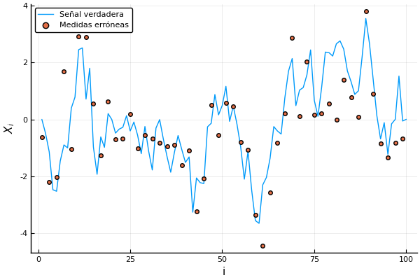

```julia
p
```

### Ejemplo rastreo de carro

Supongamos que la dinámica de un carro en $\mathbb{R}^2$ están dadas por las ley de Newton

$$ \pmb{f}(t)=m\pmb{a}(t) $$

donde $\pmb{f}$ es un vector de fuerzas actuando sobre el carro $\pmb{a}$ es el vector de aceleración y $m$ es la masa del carro.

Si tomamos $\pmb{x}=(x_1,x_2)$ como la posición del carro y fijamos $m=1$ entonces

$$ \begin{matrix} \frac{\mathrm{d}^2 x_1}{\mathrm{d}t^2} = a_1(t) \\ \frac{\mathrm{d}^2 x_2}{\mathrm{d}t^2} = a_2(t) \end{matrix}. $$

Si definimos $x_3=\frac{\mathrm{d} x_1}{\mathrm{d}t}$ y $x_4=\frac{\mathrm{d} x_2}{\mathrm{d}t}$ entonces sobtenemos un sistema de ecuaciones diferenciales ordinarias $4$-dim

$$ \frac{ \mathrm{d} }{\mathrm{d}t} \left( \begin{matrix} x_1\\x_2\\x_3\\x_4 \end{matrix} \right)= \left( \begin{matrix} 0 & 0 & 1 & 0 \\ 0 & 0 & 0 & 1 \\ 0 & 0 & 0 & 0 \\ 0 & 0 & 0 & 0 \end{matrix}\right) \left( \begin{matrix} x_1\\x_2\\x_3\\x_4 \end{matrix} \right) + \left( \begin{matrix} 0 & 0 \\ 0 & 0 \\ 1 & 0 \\ 0 & 1 \end{matrix}\right) \left( \begin{matrix} a_1 \\ a_2 \end{matrix}\right) $$

el cual reescribimos como $$ \frac{ \mathrm{d}\pmb{x}}{\mathrm{d}t} = \pmb{A}\pmb{x}+\pmb{L}\pmb{a} $$

Si discretizamos el anterior sistema de ecuaciones sobre una malla $\left\{0,\Delta t,2\Delta t,\ldots\right\}$ con $\Delta t>0$ obtenemos

$$ \left( \begin{matrix} x_{1,i}\\x_{2,i}\\x_{3,i}\\x_{4,i} \end{matrix} \right)= \left( \begin{matrix} 1 & 0 & \Delta t & 0 \\ 0 & 1 & 0 & \Delta t \\ 0 & 0 & 1 & 0 \\ 0 & 0 & 0 & 1 \end{matrix}\right) \left( \begin{matrix} x_{1,i-1}\\x_{2,i-1}\\x_{3,i-1}\\x_{4,i-1} \end{matrix} \right) + \pmb{q}_{i-1} $$

donde $\pmb{q}_{i-1}\sim \text{Normal}_4(\pmb{0},\pmb{Q})$ con $$ \pmb{Q}= \left( \begin{matrix} \frac{q_1(\Delta t)^3}{3} & 0 & \frac{q_1(\Delta t)^2}{2} & 0 \\ 0 & \frac{q_2(\Delta t)^3}{3} & 0 & \frac{q_2(\Delta t)^2}{2} \\ \frac{q_1(\Delta t)^2}{2} & 0 & q_1\Delta t & 0 \\ 0 & \frac{q_2(\Delta t)^2}{2} & 0 & q_2\Delta t \end{matrix}\right) $$

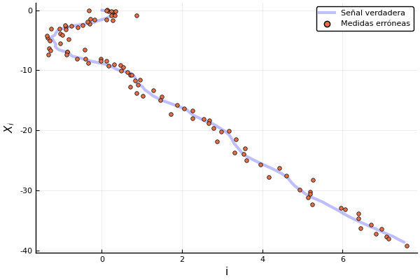

```julia
p
```

Denotemos para $j\leq n$

\begin{align*} p( \pmb{y}_n \, | \, \pmb{x}_{1:j} ) & = \mathbb{P}\left[ \pmb{Y}_n =\pmb{Y}_n \, |\, \pmb{X}_1=\pmb{x}_1,\ldots , \pmb{X}_j = \pmb{x}_j \right] \\ p( \pmb{x}_n \, | \, \pmb{x}_{1:(n-1)} ) & = \mathbb{P}\left[ \pmb{X}_n =\pmb{x}_n \, |\, \pmb{X}_1=\pmb{x}_1,\ldots , \pmb{X}_{n-1} = \pmb{x}_{n-1} \right] \end{align*}

## Teorema Kalman Filter

Para el modelo escondido de Márkov lineal Gaussiano \begin{align*} \pmb{Y}_n &= \textbf{A}_{n-1}\pmb{Y}_{n-1} + \pmb{S}_{n-1} \\ \pmb{X}_n &= \textbf{B}_n\pmb{Y}_{n} + \pmb{T}_{n} \end{align*} con $\pmb{S}_{n-1} \sim \text{Normal}_d\left( \pmb{0},\, \textbf{Q}_{n-1} \right),\; \pmb{T}_n \sim \text{Normal}_k\left( \pmb{0},\, \textbf{R}_n \right)$ se tiene que

\begin{align*} p( \pmb{y}_n \, | \, \pmb{x}_{1:(n-1)} ) &= f_{\text{Normal}(\pmb{m}_n^-,\textbf{P}_n^-)}(\pmb{y}_n) \\ p( \pmb{y}_n \, | \, \pmb{x}_{1:n} ) &= f_{\text{Normal}(\pmb{m}_n,\textbf{P}_n)}(\pmb{y}_n) \\ p( \pmb{x}_n \, | \, \pmb{x}_{1:(n-1)} ) &= f_{\text{Normal}(\textbf{B}_n\pmb{m}_n^-,\textbf{U}_n)}(\pmb{x}_n) \end{align*}

Donde

\begin{align*} \pmb{m}_n^- & = \textbf{A}_{n-1}\pmb{m}_{n-1} \\ \textbf{P}_n^- & = \textbf{A}_{n-1} \textbf{P}_{n-1}\textbf{A}_{n-1}' + \textbf{Q}_{n-1} \\ \pmb{v}_n & = \pmb{x}_{n} - \textbf{B}_n \pmb{m}_n^- \\ \textbf{U}_n & = \textbf{B}_n \textbf{P}_n^- \textbf{B}_n' + \textbf{R}_n \\ \textbf{K}_n & = \textbf{P}_n^- \textbf{B}_n'\textbf{U}_n^{-1} \\ \pmb{m}_n & = \pmb{m}_n^- + \textbf{K}_n \pmb{v}_n \\ \textbf{P}_n & =\textbf{P}_n^- -\textbf{K}_n \textbf{U}_n \textbf{K}_n' \end{align*}

### Ejemplo caminata aleatoria Gaussiana

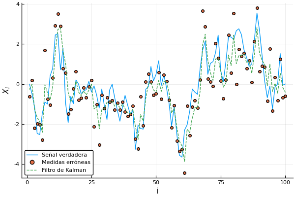

```julia
p
```

### Ejemplo rastreo de carro

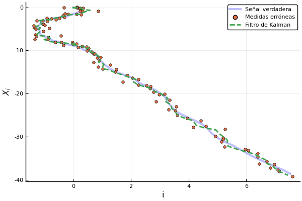

```julia
p
```

#### Lemma KF.1

Si

\begin{align*} \pmb{x} \sim \text{Normal}(\pmb{m},\pmb{P}) \\ \pmb{x}\,|\, \pmb{y} \sim \text{Normal}(H\pmb{x}+\pmb{u},\pmb{R}) \end{align*}

entonces

\begin{align*} \left(\begin{matrix} \pmb{x}\\ \pmb{y} \end{matrix}\right) & \sim \text{Normal}\left( \left(\begin{matrix} \pmb{m} \\ \pmb{H}\pmb{m}+\pmb{u} \end{matrix}\right) ,\left(\begin{matrix} \pmb{P} & \pmb{P}\pmb{H}' \\ \pmb{H}\pmb{P} & \pmb{H}\pmb{P}\pmb{H}'+\pmb{R} \end{matrix}\right) \right) \\ \\ \pmb{y} &\sim \text{Normal}\left( \pmb{H}\pmb{m}+\pmb{u},\pmb{H}\pmb{P}\pmb{H}'+\pmb{R}\right) \end{align*}

#### Lemma KF.2

Si

\begin{align*} \left(\begin{matrix} \pmb{x}\\ \pmb{y} \end{matrix}\right) & \sim \text{Normal}\left( \left(\begin{matrix} \pmb{a} \\ \pmb{b} \end{matrix}\right) ,\left(\begin{matrix} \pmb{A} & \pmb{C} \\ \pmb{C}' & \pmb{B} \end{matrix}\right) \right) \end{align*}

entonces

\begin{align*} \pmb{x} &\sim \text{Normal}(\pmb{a},\pmb{A}) \\ \pmb{y} &\sim \text{Normal}(\pmb{b},\pmb{B}) \\ \pmb{x}\,|\, \pmb{y} &\sim \text{Normal}(\pmb{a}+\pmb{C}\pmb{B}^{-1}(\pmb{y}-\pmb{b}), \pmb{A}-\pmb{C}\pmb{B}^{-1}\pmb{C}') \end{align*}

### Ejemplo No-lineal

$$ \frac{\mathrm{d}^2\alpha}{\mathrm{d}t^2}=-g\sin(\alpha)+w(t) $$

Nuevamente construimos un sistema de ecuaciones diferenciales mediante $x_1=\alpha$ y $x_2=\frac{\mathrm{d}x_1}{\mathrm{d}t}$:

$$ \frac{ \mathrm{d} }{\mathrm{d}t} \left( \begin{matrix} x_1 \\ x_2 \end{matrix} \right) = \left( \begin{matrix} x_2 \\ -g\sin(x_1) \end{matrix}\right) + \left( \begin{matrix} 0 \\ 1 \end{matrix}\right) w $$

el cual reescribimos como $$ \frac{ \mathrm{d}\pmb{x}}{\mathrm{d}t} = \pmb{f}(\pmb{x})+\pmb{L}\pmb{w} $$

Discretizando el anterior sistema obtenemos para una malla $\left\{\Delta t,\, 2\Delta t,\ldots\right\}$

\begin{align*} \left( \begin{matrix} x_{1,i} \\ x_{2,i} \end{matrix} \right) &= \left( \begin{matrix} x_{1,i-1}+x_{2,i-1}\Delta t \\ x_{2,i-1} -g\sin(x_{1,i.1})\Delta t \end{matrix}\right) + \pmb{q}_{i-1} = \pmb{f}(\pmb{x}_{i-1})+ \pmb{S}_{i-1} \\ \\ y_i &= \sin(x_{1,i})+\epsilon_i \end{align*}

con $\epsilon_i\sim\text{Normal}(0,r)$, $\pmb{S}_{i-1}\sim\text{Normal}_2(\pmb{0},\pmb{Q})$

$$ \pmb{Q}=\left( \begin{matrix} \frac{q(\Delta t)^3}{3} & \frac{q(\Delta t)^2}{2} \\ \frac{q(\Delta t)^2}{2} & q\Delta t \end{matrix}\right) $$

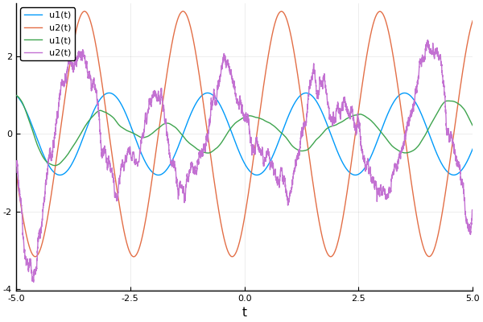

```julia
p
```

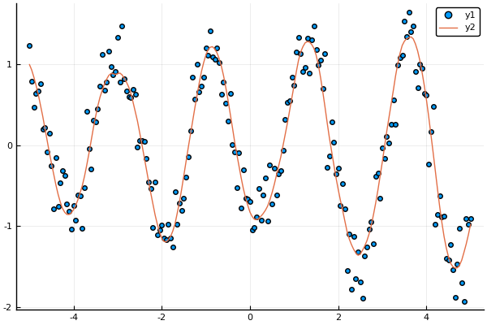

```julia
p
```

En general consideramos modelos escondidos de Márkov no lineales

\begin{align*} \pmb{Y}_n &= \textbf{f}(\pmb{Y}_{n-1}) + \pmb{S}_{n-1} \\ \pmb{X}_n &= \textbf{h}(\pmb{Y}_{n}) + \pmb{\epsilon}_{n} \end{align*}

donde

$$ \pmb{S}_{n-1} \sim \text{Normal}_d\left( \pmb{0},\, \textbf{Q}_{n-1} \right),\quad \pmb{\epsilon}_n \sim \text{Normal}_k\left( \pmb{0},\, \textbf{R}_n \right) $$

Denotamos $\pmb{J}_{\pmb{f}}(\pmb{m})$ a la matriz jacobiana de $f$ evaluada en $\pmb{m}$.

## Teorema Filtro de Kalman extendido

Para el modelo escondido de Márkov no-lineal Gaussiano aditivo \begin{align*} \pmb{Y}_n &= \textbf{f}(\pmb{Y}_{n-1}) + \pmb{S}_{n-1} \\ \pmb{X}_n &= \textbf{h}(\pmb{Y}_{n}) + \pmb{\epsilon}_{n} \end{align*} con $\pmb{S}_{n-1} \sim \text{Normal}_d\left( \pmb{0},\, \textbf{Q}_{n-1} \right),\; \pmb{\epsilon}_n \sim \text{Normal}_k\left( \pmb{0},\, \textbf{R}_n \right)$ se tiene que

\begin{align*} p( \pmb{y}_n \, | \, \pmb{x}_{1:(n-1)} ) &= f_{\text{Normal}(\pmb{m}_n^-,\textbf{P}_n^-)}(\pmb{y}_n) \\ p( \pmb{y}_n \, | \, \pmb{x}_{1:n} ) &= f_{\text{Normal}(\pmb{m}_n,\textbf{P}_n)}(\pmb{y}_n) \\ p( \pmb{x}_n \, | \, \pmb{x}_{1:(n-1)} ) &= f_{\text{Normal}(\textbf{B}_n\pmb{m}_n^-,\textbf{U}_n)}(\pmb{x}_n) \end{align*}

Donde

\begin{align*} \pmb{m}_n^- & = \textbf{f}(\pmb{m}_{n-1}) \\ \textbf{P}_n^- & = \pmb{J}_{\pmb{f}}(\pmb{m}_{n-1}) \textbf{P}_{n-1}\pmb{J}_{\pmb{f}}(\pmb{m}_{n-1})' + \textbf{Q}_{n-1} \\ \pmb{v}_n & = \pmb{x}_{n} - \pmb{h}(\pmb{m}_n^-) \\ \textbf{U}_n & = \pmb{J}_{\pmb{h}}(\pmb{m}_n^-) \textbf{P}_n^- \pmb{J}_{\pmb{h}}(\pmb{m}_n^-) + \textbf{R}_n \\ \textbf{K}_n & = \textbf{P}_n^- \pmb{J}_{\pmb{h}}(\pmb{m}_n^-)'\textbf{U}_n^{-1} \\ \pmb{m}_n & = \pmb{m}_n^- + \textbf{K}_n \pmb{v}_n \\ \textbf{P}_n & =\textbf{P}_n^- -\textbf{K}_n \textbf{U}_n \textbf{K}_n' \end{align*}

#### Lemma EKF

Si $\pmb{Y}\sim \text{Normal}(\pmb{m},\pmb{P})$, $\pmb{S}\sim \text{Normal}(\pmb{0},\pmb{Q})$ y $\pmb{X}=\pmb{f}(\pmb{Y})+\pmb{S}$ entonces

\begin{align*} \left(\begin{matrix} \pmb{Y}\\ \pmb{X} \end{matrix}\right) & \sim \text{Normal}\left( \left(\begin{matrix} \pmb{m} \\ \pmb{\mu} \end{matrix}\right) ,\left(\begin{matrix} \pmb{A} & \pmb{C} \\ \pmb{C}' & \pmb{B} \end{matrix}\right) \right) \end{align*}

con

\begin{align*} \pmb{\mu} &= \pmb{f}(\pmb{m}) \\ \pmb{B} & = \pmb{J}_{\pmb{f}}(\pmb{m}) \pmb{P} \pmb{J}_{\pmb{f}}(\pmb{m})' +\pmb{Q} \\ \pmb{A} & = \pmb{P} \pmb{J}_{\pmb{f}}(\pmb{m})' \end{align*}

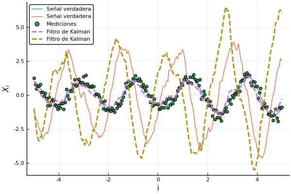

```julia
p
```

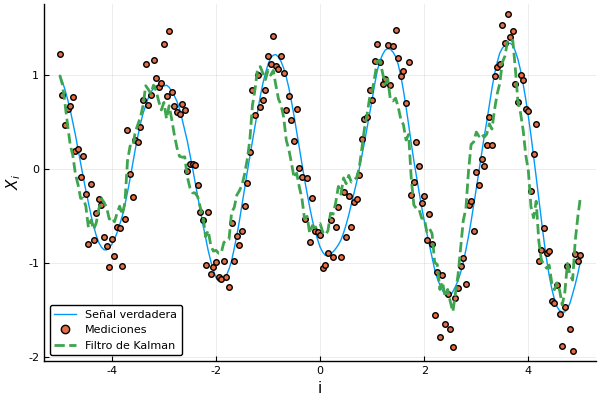

```julia
p
```

## Filtros de partículas

### Muestreo por importancia para probabilidad condicional de filtrado

La probabilidad de filtrado está dada por $$p(y_k\,|\, \pmb{x}_{1:k}),$$ en general consideremos densidades de probabilidad condicional $$p(\pmb{y}\,|\,\pmb{x}_{1:T})$$

Recordemos que podemos realizar muestreo por importancia para estimar

$$ \mathbb{E}\left[ g(\pmb{Y}) \, |\, \pmb{X}_{1:T}= \pmb{x}_{1:T} \right] = \int g(\pmb{y})p(\pmb{y}\,|\,\pmb{x}_{1:T})\mathrm{d}\pmb{y} = \frac{ \int g(\pmb{y})p( \pmb{x}_{1:T}\,|\, \pmb{y} )p(\pmb{y})\mathrm{d}\pmb{y} }{ \int p( \pmb{x}_{1:T}\,|\, \pmb{y} )p(\pmb{y})\mathrm{d}\pmb{y} } $$

mediante

\begin{align*} \mathbb{E}\left[ g(\pmb{Y}) \, |\, \pmb{x}_{1:T} \right] & = \frac{ \int \frac{ p( \pmb{x}_{1:T}\,|\, \pmb{y} )p(\pmb{y})}{\pi(\pmb{y}\,|\, \pmb{x}_{1:T})}g(\pmb{y}) \pi(\pmb{y}\,|\, \pmb{x}_{1:T}) \mathrm{d}\pmb{y} }{ \int \frac{ p( \pmb{x}_{1:T}\,|\, \pmb{y} )p(\pmb{y})}{\pi(\pmb{y}\,|\, \pmb{x}_{1:T})}\pi(\pmb{y}\,|\, \pmb{x}_{1:t})\mathrm{d}\pmb{y} } \\ & \approx \frac{ \frac{1}{n}\sum_{j=1}^n \frac{ p( \pmb{x}_{1:T}\,|\, \pmb{Y}_j )p(\pmb{Y}_j)}{\pi(\pmb{Y}_j\,|\, \pmb{x}_{1:T})}g(\pmb{Y}_j) }{ \frac{1}{n} \sum_{j=1}^n \frac{ p( \pmb{x}_{1:T}\,|\, \pmb{Y}_j )p(\pmb{Y}_j)}{\pi(\pmb{Y}_j\,|\, \pmb{x}_{1:T})}} = \sum_{j=1}^n w_j g(\pmb{Y}_j) \end{align*}

con $Y_1,\ldots Y_n \stackrel{\text{i.i.d.}}{\sim}\mathcal{L}(\pi(\pmb{y}\,|\,\pmb{x}_{1:T}))$ y $$w_j=\left( \sum_{j=1}^n \frac{ p( \pmb{x}_{1:T}\,|\, \pmb{Y}_j )p(\pmb{Y}_j)}{\pi(\pmb{Y}_j\,|\, \pmb{x}_{1:T})}g(\pmb{Y}_j)\right)\big/ \left( \sum_{j=1}^n \frac{ p( \pmb{x}_{1:T}\,|\, \pmb{Y}_j )p(\pmb{Y}_j)}{\pi(\pmb{Y}_j\,|\, \pmb{x}_{1:T})} \right)$$.

Observemos que así las cosas podemos aproximar

$$ p(\pmb{y}\,|\, \pmb{x}_{1:T})\approx \sum_{j=1}^n w_j\delta(\pmb{y}-\pmb{Y}_i) $$

### Muestreo por importancia secuencial

La idea es utilizar muestreo por importancia para $p(\pmb{y}_{1:i}\, |\,\pmb{x}_{1:i})$ de tal forma que la aproximación por importancia dada por pesos $w_{i,j}$ pueda ser calculada de forma recursiva. Sea $\pi(\pmb{y}_{1:i}\,|\,\pmb{x}_{1:i})$ la distribución de importancia usada para aproximar $p(\pmb{y}_{1:i}\, |\,\pmb{x}_{1:i})$ y $w_{i,j}$ los pesos asociados, es decir

$$ w_{i.j}\propto \frac{ p( \pmb{x}_{1:i}\,|\, \pmb{Y}_{1:i}^{(j)} )p(\pmb{Y}_{1:i}^{(j)})}{\pi(\pmb{Y}_j\,|\, \pmb{x}_{1:i})} \propto \frac{ p(\pmb{Y}_{1:i}^{(j)} \, |\,\pmb{x}_{1:i}) }{\pi(\pmb{Y}_{1:i}^{(j)}\,|\,\pmb{x}_{1:i})} $$

con $\pmb{Y}_{1:i}^{(j)} \stackrel{\text{i.i.d.}}{\sim}\mathcal{L}(\pi(\pmb{y}_{1:i}\,|\,\pmb{x}_{1:i})), \; j\in\left\{1,\ldots , n\right\}$.

Por otro lado

\begin{align*} p(\pmb{y}_{1:(i+1)} \, |\,\pmb{x}_{1:(i+1)}) & \propto p(\pmb{x}_{i+1}\,|\, \pmb{y}_{1:(i+1)},\pmb{x}_{1:i})p(\pmb{y}_{1:(i+1)}\,|\, \pmb{x}_{1:i} ) \\ & = p(x_{i+1} \, |\, y_{i+1})p(y_{(i+1)}\,|\, \pmb{y}_{1:i},\pmb{x}_{1:i})p(\pmb{y}_{1:i} \, |\, \pmb{x}_{1:i}) \\ & = p(x_{i+1} \, |\, y_{i+1})p(y_{(i+1)}\,|\, y_{i})p(\pmb{y}_{1:i} \, |\, \pmb{x}_{1:i}); \end{align*}

con lo que

$$ w_{i+1.j}\propto \frac{ p( \pmb{x}_{1:(i+1)}\,|\, \pmb{Y}_{1:(i+1)}^{(j)} )p(\pmb{Y}_{1:(i+1)}^{(j)})}{\pi(\pmb{Y}_j\,|\, \pmb{x}_{1:(i+1)})} \propto \frac{ p(\pmb{Y}_{1:(i+1)}^{(j)} \, |\,\pmb{x}_{1:(i+1)}) }{\pi(\pmb{Y}_{1:(i+1)}^{(j)}\,|\,\pmb{x}_{1:(i+1)})}\propto \frac{p(x_{i+1} \, |\, Y_{i+1}^{(j)})p(Y_{i+1}^{(j)}\,|\, Y_i^{(j)})p(\pmb{Y}_{1:i}^{(j)} \, |\, \pmb{x}_{1:i})}{\pi(\pmb{Y}_{1:(i+1)}^{(j)}\,|\,\pmb{x}_{1:(i+1)})} $$

Si suponemos que las distribuciónes de importancia tienen una estructura recursiva

$$ \pi(\pmb{y}_{1:(i+1)} \,|\,\pmb{x}_{1:(i+1)}) = \pi( y_{i+1} \,|\,\pmb{y}_{1:i},\pmb{x}_{1:(i+1)}) \pi(\pmb{y}_{1:i} \,|\,\pmb{x}_{1:i}) $$

entonces

\begin{align*} w_{i+1.j}\propto \frac{p(x_{i+1} \, |\, Y_{i+1}^{(j)})p(Y_{i+1}^{(j)}\,|\, Y_i^{(j)})p(\pmb{Y}_{1:i}^{(j)} \, |\, \pmb{x}_{1:i})}{\pi(\pmb{Y}_{1:(i+1)}^{(j)}\,|\,\pmb{x}_{1:(i+1)})} = \frac{p(x_{i+1} \, |\, Y_{i+1}^{(j)})p(Y_{i+1}^{(j)}\,|\, Y_i^{(j)}) }{\pi( Y_{i+1} \,|\,\pmb{Y}_{1:i},\pmb{x}_{1:(i+1)}) }\frac{p(\pmb{Y}_{1:i}^{(j)} \, |\, \pmb{x}_{1:i})}{ \pi(\pmb{Y}_{1:i} \,|\,\pmb{x}_{1:i}) } \propto \frac{p(x_{i+1} \, |\, Y_{i+1}^{(j)})p(Y_{i+1}^{(j)}\,|\, Y_i^{(j)}) }{\pi( Y_{i+1} \,|\,\pmb{Y}_{1:i},\pmb{x}_{1:(i+1)}) } w_{i.j} \end{align*}

### Algoritmo muestreo por importancia secuencial

1) Genere $\left\{ y_1^{(j)} \right\}_{j=1}^n\stackrel{\text{i.i.d.}}{\sim}\mathcal{L}(p_1)$ con $p_1$ una distribución incial, y tome $w_{1,j}=\frac{1}{n}$, $j\in\left\{1,\ldots , n\right\}$. Inicialize $i=2$

2) Para $i\in\left\{2,\ldots , T\right\}$

2a) Genere muestras de importancia $Y_i^{(j)} \sim \mathcal{L}\left( \pi(y_i\, | \, \pmb{y}_{1:(i-1)}^{(j)}, \pmb{x}_{1:i}) \right)$ para $i\in\left\{2,\ldots , T\right\}$.

2b) Calcule pesos

$$ w_{i,j} \propto w_{i-1,j}\frac{p(x_i \, |\, Y_i^{(j)})p(Y_i^{(j)}\,|\, Y_{i-1}^{(j)}) }{\pi( Y_i \,|\,\pmb{Y}_{1:(i-1)},\pmb{x}_{1:i}) } $$

de tal forma que sumen 1.

Es coveniente elegir las distribuciones de importancia de tal forma que definan un proceso Markoviano con lo que

$$ \pi( y_i \,|\,\pmb{y}_{1:(i-1)},\pmb{x}_{1:i}) = \pi( y_i \,|\, y_{i-1},x_i). $$

El filtro bootstrap está definido por la elección

$$ \pi( y_i \,|\,\pmb{y}_{1:(i-1)},\pmb{x}_{1:i}) = \pi( y_i \,|\, y_{i-1},x_i)= p(y_i\,|\, y_{i-1}) $$

con lo que

$$ w_{i,j} \propto p(x_i \, |\, Y_i^{(j)})$$

.

En lo siguiente estaremos haciendo uso del filtro bootstrap.

```julia
function seq_imp_samp(X::Array{Float64,2},m::Int64,F::Array{Float64,2},Q::Array{Float64,2},H::Array{Float64,2},R::Array{Float64,2},y₀::Array{Float64,1}=[0.0,0.0,0.1,-0.1])
    d = length(y₀)
    n = size(X,1)
    Y = zeros(n,d,m)
    W = zeros(n,m)
    log_W = zeros(n,m)
    Y[1,:,:] = rand( MvNormal(y₀), m)
    W[1,:] .= 1.0/m
    log_W[1,:] .= -log(m)
    W[1,:] = exp.( log_W[1,:] .- maximum(log_W[1,:]) .- log(sum(exp.(log_W[1,:] .- maximum(log_W[1,:])))) )
    for i in 2:n
        for j in 1:m
            Y[i,:,j] = rand( MvNormal(F*Y[i-1,:,j],Symmetric(Q + UniformScaling(0.0000001))))
        end
        log_W[i,:] = log_W[i-1,:] .+ [ logpdf(MvNormal(H*Y[i,:,j],Symmetric(R + UniformScaling(0.0000001))),X[i,:]) for j in 1:m]
        W[i,:] = exp.( log_W[i,:] .- maximum(log_W[i,:]) .- log(sum(exp.(log_W[i,:] .- maximum(log_W[i,:])))) )
    end
    return Y, W
end
```

```
seq_imp_samp (generic function with 4 methods)
```

Desfortunadamente el anterior algoritmo suele tener problemas numéricos por los que los pesos se degeneran de tal manera que solamente uno es distinto de cero.

```julia
SIS = seq_imp_samp(X,100,F,Q,H,R);
```

```julia
SIS[2]
```

```
100×100 Array{Float64,2}:
 0.01         0.01         …  0.01       0.01         0.01
 0.00946538   0.00961085      0.0105625  0.00941281   0.00928358
 0.00845449   0.00883396      0.0162787  0.00893469   0.00776392
 0.00734005   0.00311028      0.0247748  0.0117822    0.00648196
 0.00845478   0.000219353     0.0219118  0.0169145    0.00279917
 0.00104386   0.00400096   …  0.0227771  0.0112479    0.00434984
 5.85979e-6   0.00017035      0.0423583  0.00135545   0.00713101
 6.78174e-10  6.00399e-10     0.137093   1.04221e-5   0.0290419
 5.23189e-13  1.81735e-15     0.252331   5.66582e-7   0.0300728
 2.09664e-18  1.10582e-25     0.48324    4.26572e-10  0.00458862
 1.19132e-23  7.08757e-34  …  0.614605   1.5954e-11   0.00110147
 6.45421e-31  2.55522e-48     0.697228   9.15394e-15  2.75823e-5
 3.14898e-48  2.74524e-68     0.584726   6.29614e-20  0.000254629
 ⋮                         ⋱
 0.0          0.0             0.0        0.0          0.0
 0.0          0.0             0.0        0.0          0.0
 0.0          0.0          …  0.0        0.0          0.0
 0.0          0.0             0.0        0.0          0.0
 0.0          0.0             0.0        0.0          0.0
 0.0          0.0             0.0        0.0          0.0
 0.0          0.0             0.0        0.0          0.0
 0.0          0.0          …  0.0        0.0          0.0
 0.0          0.0             0.0        0.0          0.0
 0.0          0.0             0.0        0.0          0.0
 0.0          0.0             0.0        0.0          0.0
 0.0          0.0             0.0        0.0          0.0
```

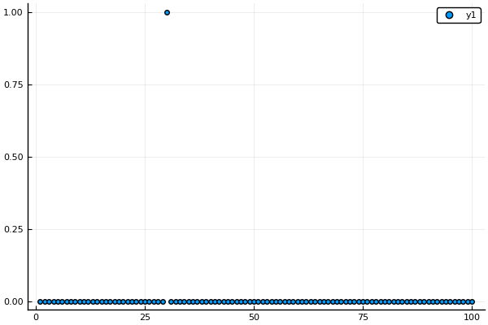

```julia
scatter(SIS[2][end,:])
```

```julia
function seq_imp_resamp(X::Array{Float64,2},m::Int64,F::Array{Float64,2},Q::Array{Float64,2},H::Array{Float64,2},R::Array{Float64,2},y₀::Array{Float64,1}=[0.0,0.0,0.1,-0.1])
    d = length(y₀)
    n = size(X,1)
    Y = zeros(n,d,m)
    W = zeros(n,m)
    log_W = zeros(n,m)
    Y[1,:,:] = rand( MvNormal(y₀), m)
    W[1,:] .= 1.0/m
    log_W[1,:] .= -log(m)
    W[1,:] = exp.( log_W[1,:] .- maximum(log_W[1,:]) .- log(sum(exp.(log_W[1,:] .- maximum(log_W[1,:])))) )
    for i in 2:n
        for j in 1:m
            Y[i,:,j] = rand( MvNormal(F*Y[i-1,:,j],Symmetric(Q + UniformScaling(0.0000001))))
        end
        log_W[i,:] = log_W[i-1,:] .+ [ logpdf(MvNormal(H*Y[i,:,j],Symmetric(R + UniformScaling(0.0000001))),X[i,:]) for j in 1:m]
        W[i,:] = exp.( log_W[i,:] .- maximum(log_W[i,:]) .- log(sum(exp.(log_W[i,:] .- maximum(log_W[i,:])))) )
        Y[i,:,:] = Y[i,:,rand(Categorical(W[i,:]),m)]
        W[i,:] .= 1.0/m
        log_W[i,:] .= -log(m)
    end
    return Y, W
end
```

```
seq_imp_resamp (generic function with 2 methods)
```

```julia
SIR = seq_imp_resamp(X,100,F,Q,H,R);
```

```julia
SIR[2]
```

```
100×100 Array{Float64,2}:
 0.01  0.01  0.01  0.01  0.01  0.01  …  0.01  0.01  0.01  0.01  0.01  0.01
 0.01  0.01  0.01  0.01  0.01  0.01     0.01  0.01  0.01  0.01  0.01  0.01
 0.01  0.01  0.01  0.01  0.01  0.01     0.01  0.01  0.01  0.01  0.01  0.01
 0.01  0.01  0.01  0.01  0.01  0.01     0.01  0.01  0.01  0.01  0.01  0.01
 0.01  0.01  0.01  0.01  0.01  0.01     0.01  0.01  0.01  0.01  0.01  0.01
 0.01  0.01  0.01  0.01  0.01  0.01  …  0.01  0.01  0.01  0.01  0.01  0.01
 0.01  0.01  0.01  0.01  0.01  0.01     0.01  0.01  0.01  0.01  0.01  0.01
 0.01  0.01  0.01  0.01  0.01  0.01     0.01  0.01  0.01  0.01  0.01  0.01
 0.01  0.01  0.01  0.01  0.01  0.01     0.01  0.01  0.01  0.01  0.01  0.01
 0.01  0.01  0.01  0.01  0.01  0.01     0.01  0.01  0.01  0.01  0.01  0.01
 0.01  0.01  0.01  0.01  0.01  0.01  …  0.01  0.01  0.01  0.01  0.01  0.01
 0.01  0.01  0.01  0.01  0.01  0.01     0.01  0.01  0.01  0.01  0.01  0.01
 0.01  0.01  0.01  0.01  0.01  0.01     0.01  0.01  0.01  0.01  0.01  0.01
 ⋮                             ⋮     ⋱        ⋮
 0.01  0.01  0.01  0.01  0.01  0.01     0.01  0.01  0.01  0.01  0.01  0.01
 0.01  0.01  0.01  0.01  0.01  0.01     0.01  0.01  0.01  0.01  0.01  0.01
 0.01  0.01  0.01  0.01  0.01  0.01  …  0.01  0.01  0.01  0.01  0.01  0.01
 0.01  0.01  0.01  0.01  0.01  0.01     0.01  0.01  0.01  0.01  0.01  0.01
 0.01  0.01  0.01  0.01  0.01  0.01     0.01  0.01  0.01  0.01  0.01  0.01
 0.01  0.01  0.01  0.01  0.01  0.01     0.01  0.01  0.01  0.01  0.01  0.01
 0.01  0.01  0.01  0.01  0.01  0.01     0.01  0.01  0.01  0.01  0.01  0.01
 0.01  0.01  0.01  0.01  0.01  0.01  …  0.01  0.01  0.01  0.01  0.01  0.01
 0.01  0.01  0.01  0.01  0.01  0.01     0.01  0.01  0.01  0.01  0.01  0.01
 0.01  0.01  0.01  0.01  0.01  0.01     0.01  0.01  0.01  0.01  0.01  0.01
 0.01  0.01  0.01  0.01  0.01  0.01     0.01  0.01  0.01  0.01  0.01  0.01
 0.01  0.01  0.01  0.01  0.01  0.01     0.01  0.01  0.01  0.01  0.01  0.01
```

```
┌ Info: Saved animation to
│   fn = /home/workstation/Documents/Simulacion/anim_filtro_particulas.gif
└ @ Plots /home/workstation/.julia/packages/Plots/cc8wh/src/animation.jl:98
```

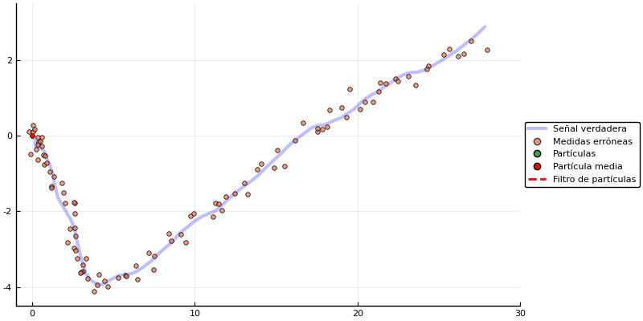

```julia
gif(anim_filtro_particulas, "anim_filtro_particulas.gif", fps = 10)
```

```
┌ Info: Saved animation to
│   fn = /home/workstation/Documents/Simulacion/anim_filtro_particulas_1000.gif
└ @ Plots /home/workstation/.julia/packages/Plots/cc8wh/src/animation.jl:98
```

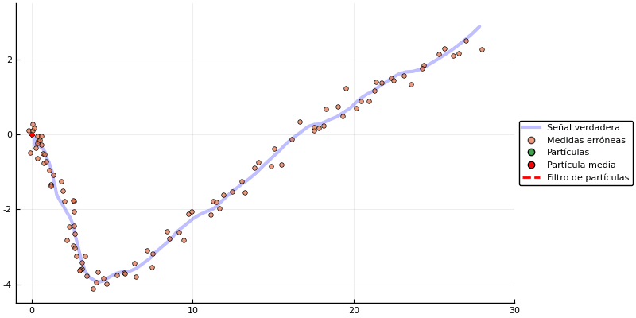

```julia
gif(anim, "anim_filtro_particulas_1000.gif", fps = 10)
```